# Writing Sample: Hemodynamics and Intraoperative Fluids

Sven Halvorson

10/21/2020

### Preface

This is the methods and results section of a manuscript that is in development at the time of me posting this. The main goal of this project was to analyze alternative outcomes from a previous clinical trial. For this project I contributed almost all of the data processing, statistical analyses, figures, tables, and writing. I had assistance selecting the statistical methods and with revisions to the writing.

### Methods

#### Study Population

The data for this study comes from the 2018 trial ‘Effect of Intraoperative Goal-directed Balanced Crystalloid versus Colloid Administration on Major Postoperative Morbidity: A Randomized Trial’ by Kabon et al$^1$. This trial consisted of adult patients under 80 years of age undergoing elective, moderate to high risk abdominal surgeries expected to last at least two hours. Patients were excluded for having an ASA status over III, a BMI over 35, a creatinine clearance under 30 ml/min, an estimated cardiac ejection fraction < 35%, severe COPD, known coagulopathies, or esophogeal/aortic abnormalities. The final sample for this trial consisted of 1,057 patents.

Patients received 5-7 ml/kg of lactated Ringer’s solution during induction and then were randomized to receive goal directed fluid replacement with either crystalloid (lactated Ringer’s solution) or colloid (hydroxyethyl starch 6%) solutions. Fluid boluses were administered in response to stroke volume and corrected aortic flow times in accordance with a previously established algorithm. Although some patients in the colloid group never received a post-induction bolus administration, they were still considered part of the colloid group by the intent-to-treat principle.

The outcomes of interest for our study were not always recorded during the trial. As a result, we used subsets of the population for our various analyses.

#### Measurements

Our primary outcome of interest was the time-weighted average (TWA) of cardiac index (CI). In the trial, cardiac index was measured intraoperatively at ten minute intervals. Cardiac index was also measured before and after a bolus administration; however, the exact timings of these measurements are not known. As a result, when computing the TWA of cardiac index, only the 10 minute interval measurements with time stamps were used. The TWA of CI was calculated as the average CI for a patient during the surgery while assuming a straight-line relationship between consecutive CI measurements. Technically, the time weighted average was computed as follows:

$$\text{TWA of CI} = \frac{1}{T}\sum_{k=1}^{N-1}\frac{\text{CI}_k+\text{CI}_{k+1}}{2}(t_{k+1}-t_k)$$

Where $CI_k$ is the $k^{th}$ cardiac index measurement, $t_k$ is the time of the $k^{th}$ measurement, and $T$ is the total time from the first to last observation.

Additionally, we excluded any cardiac index measurements less than 0.8 L/min/m$^2$ or greater than 8 L/min/m$^2$ as they are likely to be recording errors.

From the data, we observed that 8% of the patients had no cardiac index/output recorded at the prescribed 10 minute intervals. We investigated the distribution of missing values between the two treatment groups as well as possible relationships between missing of the outcomes and baseline variables.

One of our secondary outcomes was the generalized average real variability$^2$ (ARV) of mean arterial pressure (MAP), which was computed as follows:

$$\textrm{Generalized ARV} = \frac{1}{T}\sum_{k=1}^{N-1} \left|{BP}_{k+1}-{BP}_{k}\right|$$

Where $T$ is the number of minutes from the first blood pressure measurement to the last and $BP_{k}$ is the $k^{th}$ blood pressure measurement. MAP measurements over 250 mmHg were assumed to be recording errors and were removed.

#### Statistical analysis

*Confounder control:* In the 2018 trial, the randomized groups were well balanced on most of the demographic factors collected. The absolute standardized difference (ASD) for smoking status was 0.12 and all others had an ASD < 0.1. The primary and secondary analyses required us to subset the data to remove patients with missing outcome variables and therefore the balance on baseline variables could potentially be altered. Our strategy to control for confounding in all analyses was as follows: if none of the baseline factors had an ASD > 0.1, no adjustments were made. If only a small handful of the baseline factors were imbalanced, the imbalanced factors were added to models. Otherwise we had planned to develop a propensity score model and use inverse probability of treatment weighting (IPTW) when assessing the treatment effect on outcome variables. However, the latter was not needed.

*Primary analysis:* We assessed the treatment effect on mean TWA of cardiac index using a 2-sample t-test either with or without inverse weighting by the PS, as indicated. If that outcome was not normally distributed we attempted a transformation, and if not successful, we conducted a Wilcoxon rank-sum test. If only a few variables were imbalanced, the treatment effect was assessed in a multivariable linear model while adjusting for the imbalanced variables.

*Sensitivity analysis 1 (missing values):* We repeated the primary analysis using imputed values for the TWA of CI. Conservatively, patients with missing outcomes were assigned to the overall (for combined groups) 75th percentile TWA CI if they were in the crystalloid group and the 25th percentile if they were in the colloid group. This imputation and analysis was repeated using the overall largest and smallest observed values.

As an additional investigation into possible effects of missing data, we created univariate logistic models predicting the presence of a missing TWA of cardiac index as a function of the baseline variables. We then repeated the primary analysis adjusting for all baseline variables that were associated with missing outcomes at the α=0.05 level.

*Sensitivity analysis 2 (repeated measures model):* In addition to analyzing the TWA of cardiac index, we also modeled the intraoperative cardiac index as a time series. A repeated measures model with an autoregressive (AR(1)) correlation structure was fit to adjust for within-patient correlation. No imputation on missing outcomes was done for this analysis.

*Secondary analysis 1 (immediate effect of bolus on CI):* We assessed the immediate effect of a bolus by computing the change in CI from before to after bolus administrations. A repeated measures linear model with unstructured or AR(1) correlation was used to account for correlation within a patient’s repeated measurements. The difference in mean changes in CI between groups was tested.

*Secondary analysis 2 (duration of effect of bolus on FTc):* We conducted a time to event analysis in order to assess differences in duration of effect between the two fluid choices. The intervals used began at the time of a bolus administration and ended at a subsequent administration. The last bolus for each patient was considered right censored at the end of surgery. A Cox proportional hazards frailty model was created to assess differences in time until the next bolus between groups. The frailty model considers patient as a random effect in order to account for correlation in the repeated measurements within subjects. We also assessed the interaction between the sequential (i.e., 1$^{st}$ 2$^{nd}$, 3$^{rd}$, …) bolus number and treatment group.

*Secondary analysis 3 (effect of fluids on ARV of MAP):* We assessed differences in the ARV of MAP between the two groups using a two sample independent t-test if the groups are balanced, a linear model if a small number of factors were imbalanced, and a weighted (IPTW) t-test if propensity score methods were required.

*Heterogeneity of treatment effect:* We assessed potential interactions between the effect of fluid choice and these specific baseline risk factors: age (>=70, <70 years), history of cardiac disease, preoperative creatinine (> 2, <=2 mg/dL), insulin dependent diabetes, and ASA status (III vs I,II). A linear model was fit with fixed effects of fluid choice, the baseline variable, and their interaction and TWA of CI as outcome.

SAS statistical software, Carey, NC, and the R programming language were used for all analyses. A significance level of α=0.05 was used for the primary and secondary hypotheses. A significance level of α=0.15 was used for tests of heterogeneity of treatment effect and then an significance criterion of 0.05 with possible Bonferroni corrections was used for pairwise comparisons.

### Results

#### Participants

Among the 1,057 patients in the original trial, 7.9% of patients had no cardiac index measurements with a known time stamp. This left us with a total of 973 patients for the primary analysis. Among the 84 patients not used for the primary analysis, 43 belonged to the colloid group and 41 were from the crystalloid group. This difference was deemed acceptable to proceed. A summary of the baseline characteristics and intraoperative factors for this subset are given in Table 1.

Our restriction on the range of cardiac index measurements between 0.8 and 8 L/min/m$^2$ and MAP less than 250 mmHg removed less than half of a percent of each of these measurements and did not remove any patients from the sample.

#### Confouding adjustment

After removing patients without a measurable TWA of CI, smoking status remained imbalanced (ASD = 0.11) and preoperative hemoglobin became imbalanced (ASD = 0.10). As a result, these factors were adjusted for in the primary analysis and secondary analysis 3. Four patients had missing hemoglobin measurements and one had an unreasonably high value. These patients were assigned the median hemoglobin value for the entire sample. The subset of patients with at least one bolus administration was only imbalanced on smoking status (ASD = 0.11) and thus this was the only variable adjusted for in secondary analyses 1 and 2.

#### Primary analysis

Our primary analysis used a linear model with adjustments for smoking status and preoperative hemoglobin to assess the mean difference in TWA of CI between the crystalloid and colloid group. The colloid group exhibited a significantly higher TWA of CI than the crystalloid group (difference in L/min/m$^2$ (95% CI): 0.20 (0.11, 0.29), P < 0.001). The results of the primary analysis and sensitivity analyses are given in Table 2.

#### Sensitivity analyses

We conducted sensitivity analyses on the TWA of cardiac index using imputed missing values at the quartiles, at the extremes, and with adjustments for variables associated with missing outcomes. We also modeled the cardiac index as a time series (instead of using TWA for each patient) using a repeated measures model with an AR(1) correlation structure. All of our sensitivity analyses except imputation at the extremes were consistent with the primary results. Imputation at the extremes yielded a significant but opposite result. The variables that were associated with missing outcomes were preoperative albumin, ASA status, preoperative bowel preparation, and smoking status.

#### Secondary analyses

When we assessed the immediate effect of a bolus using a repeated measures model with an AR(1) correlation structure, we found a significantly larger increase in the cardiac index of the colloids group (difference in L/min/m$^2$ (95% CI): 0.09 (0.06, 0.12), P<0.001). The estimated mean (SE) increase of cardiac index after a bolus was 0.37 (0.02) L/min/m$^2$ for the crystalloid group and 0.46 (0.02) L/min/m$^2$ for the colloid group. For secondary analyses 1 and 2, we removed 13.7% of the patients due to lack of a bolus administration leaving us with 912 patients for use in these analyses. The results of all of our secondary analyses are given in Table 3.

We examined the duration of effect of a bolus using a Cox proportional hazards frailty model. A significantly lower hazard of the need for an additional bolus was found in the colloid group (HR (95% CI): 0.60 (0.55, 0.66), P < 0.001). The data exhibited minor deviations from the proportional hazard assumption when examined graphically.

Finally, we examined the generalized average real variation in mean arterial pressure between the two groups by fitting a linear model and did not find a significant difference in ARV of MAP (difference in mmHg (95% CI): -0.03 (-0.07, 0.02) , P = 0.229). A total of 86 patients were removed from the initial population due to lack MAP values leaving us with a sample of 971 patients for this analysis.

#### Limitations

Due to associations between missing primary outcomes and baseline characteristics, the generalizability of these results may be slightly different than for the original trial. The results of our sensitivity analyses adjusting for these variables were consistent with the primary analysis results so it is unlikely that the results are biased due to missing data. Because the administrations were given in response to corrected flow time values, not cardiac index, secondary analyses 1 and 2 may be difficult to interpret in conjunction with the primary analysis.

### Table 1: Cohort description (N = 973)

| Variable | Crystalloids | Colloids | ASD |
| --- | --- | --- | --- |
| N | 493 | 480 |  |
| **Demographics & Medical History** |  |  |  |
| Age, yrs | 52 ± 16 | 51 ± 16 | 0.03 |
| BMI | 28 ± 30 | 27 ± 27 | 0.02 |
| Female, No. (%) | 249 (50) | 226 (47) | 0.07 |
| ASA physical status, No. (%) |  |  | 0.04 |
| I | 43 (8.7) | 43 (9.1) |  |
| II | 286 (58) | 282 (60) |  |
| III | 163 (33) | 148 (31) |  |
| Race (white), No. (%) | 468 (95) | 454 (95) | 0.02 |
| Pulmonary disease | 35 (7.3) | 40 (8.5) | 0.04 |
| Cardiovascular disease | 143 (29) | 128 (27) | 0.05 |
| Neurological disease | 21 (4.4) | 23 (5.0) | 0.03 |
| Diabetes | 33 (6.9) | 36 (7.8) | 0.04 |
| Insulin use | 7 (1.5) | 11 (2.4) | 0.07 |
| History of PONV | 46 (9.3) | 41 (8.5) | 0.03 |
| Alcohol > 25 drinks per week | 28 (6.2) | 23 (5.3) | 0.04 |
| Smoking status |  |  | 0.11 |
| None | 274 (56) | 247 (52) |  |
| Current | 88 (18) | 82 (17) |  |
| Former | 75 (15) | 90 (19) |  |
| Unknown | 56 (11) | 61 (13) |  |
| Preoperative bowel preparation |  |  | 0.02 |
| Home | 56 (11) | 52 (11) |  |
| Hospital | 103 (21) | 103 (22) |  |
| None | 333 (68) | 321 (67) |  |
| **Preoperative Laboratory Values** |  |  |  |
| Creatinine, mg/dL | 0.84 ± 0.19 | 0.9 ± 0.7 | 0.08 |
| Albumin, g/dL | 4.30 [3.99, 4.70] | 4.30 [4.00, 4.70] | 0.04 |
| Hemoglobin, gm/dL | 13.2 ± 2.0 | 14 ± 6 | 0.10 |
| Hematocrit, % | 39 ± 5 | 39 ± 5 | 0.03 |
| Normotest/PT, sec | 98 [76, 115] | 102 [74, 119] | 0.09 |
| APTT STA, sec | 0 ± 553 | 35 ± 22 | 0.09 |
| **Intraoperative factors** |  |  |  |
| Duration of anesthesia, hrs | 4.5 [3.6, 5.7] | 4.4 [3.3, 5.7] | 0.07 |
| Duration of surgery, hrs | 3.4 [2.5, 4.7] | 3.3 [2.4, 4.5] | 0.08 |
| Crystalloid, ml | 3207 [2300, 4390] | 1800 [1200, 2400] | 0.68 |
| Colloid, ml | 0 [0, 0] | 1000 [500, 1500] | 1.07 |
| Blood given, ml | 0 [0, 0] | 0 [0, 0] | 0.11 |
| Estimated blood lost, ml | 250 [100, 500] | 250 [100, 500] | 0.05 |
| Estimated urine output, ml | 340 [200, 500] | 320 [200, 502] | 0.06 |
| Other fluids, ml | 50 [0, 450] | 100 [0, 400] | 0.07 |
| TWA MAP, mmHg | 80 ± 9 | 79 ± 9 | 0.03 |
| End-tidal PCO2 , % | 34.2 ± 2.3 | 34.6 ± 2.4 | 0.17 |
| Sevoflurane MAC, hrs | 1.3 [0.7, 3.3] | 1.4 [0.6, 3.2] | 0.02 |

Summary statistics are given as either a mean ± standard deviation, median [Q1, Q3], or a count (%). The absolute standardized difference (ASD) measures the mean difference between the crystalloid and colloid groups on a common scale.

### Table 2: Primary analysis of TWA of CI and sensitivity analyses

| Analysis | N | Estimated Difference (95% CI) | P |
| --- | --- | --- | --- |
| Primary, linear model | 973 | 0.20 (0.11, 0.29) | < 0.001 |
| Imputed CI at quartiles | 1,057 | 0.11 (0.03, 0.20) | 0.010 |
| Imputed CI at extreme values | 1,057 | -0.21 (-0.34, -0.09) | 0.001 |
| Adjusted for variables associated with missingess | 834 | 0.20 (0.10, 0.31) | < 0.001 |
| Repeated measures model | 973$^1$ | 0.20 (0.17, 0.22) | < 0.001 |

$^1$ A total of 21,525 measurements were used across 973 patients

### Table 3: Secondary analyses

| Analysis | N patients | Estimate (95% CI) | P |
| --- | --- | --- | --- |
| Immediate effect of a bolus$^1$ | 912 | 0.09 (0.06, 0.12) | < 0.001 |
| Duration of effect of a bolus$^2$ | 912 | 0.60 (0.55, 0.66) | < 0.001 |
| ARV of MAP$^3$ | 971 | -0.03 (-0.07, 0.02) | 0.229 |

$^1$ Estimates are the difference (colloids - crystalloids) in change in CI (L/min/m$^2$) immediately following a bolus administration. The results were produced from a repeated measures model. A total of N = 4,774 observations were used.

$^2$ Estimates are the hazard ratio (colloids to crystalloids) of requiring another bolus administration. Analysis was conducted using a shared frailty model. A total of N = 4,890 observations were used.

$^3$ Estimates are the difference (colloids - crystalloids) in average real variation in mean arterial pressure (mmHg). Analysis was done using a linear model.

### Figure 1: Distribution of time weighted averages of cardiac index

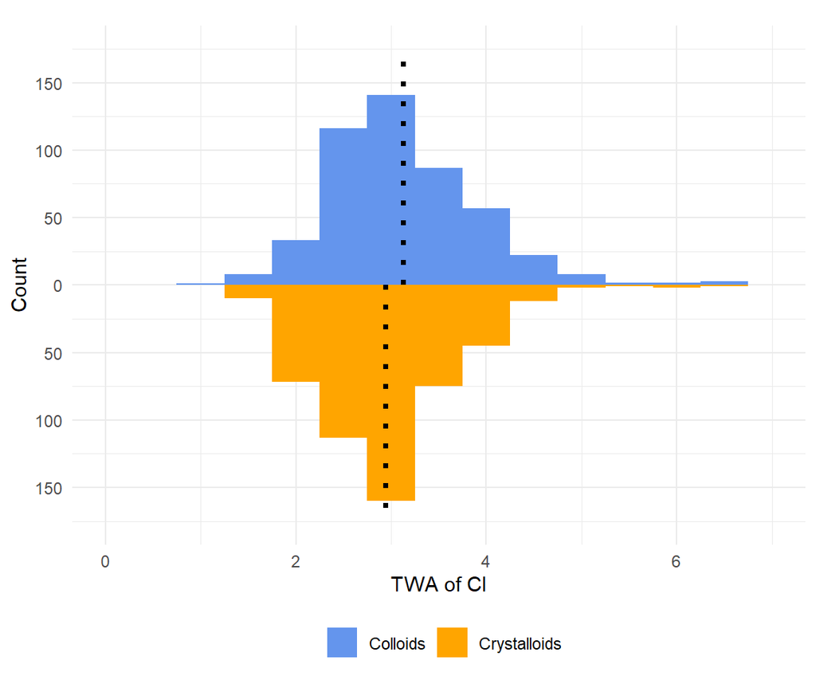

The TWA of cardiac index is plotted by choice of fluids. Group means are given as dotted lines. The TWA of cardiac index was compared between fluid groups using a linear model with adjustments for smoking status and preoperative hemoglobin. Using N=973 measurements, a significant difference in means was detected.

### Figure 2: Density of cardiac index changes following a bolus administration

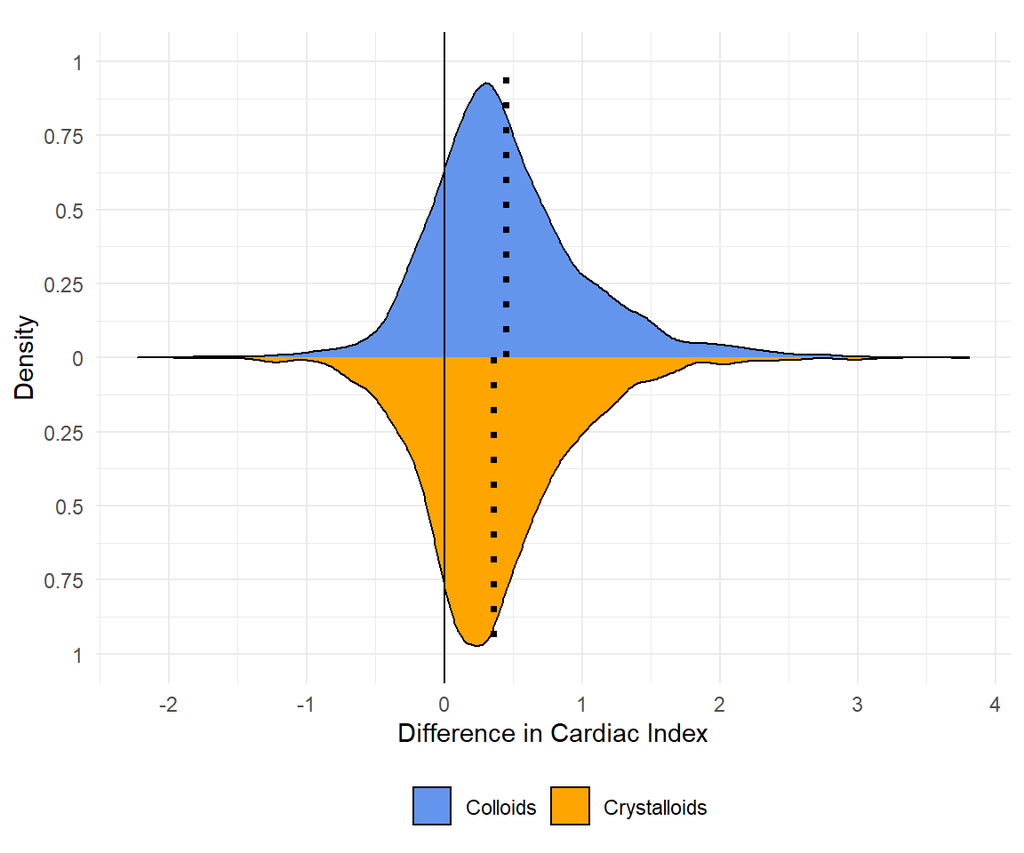

The distribution of all 4,774 changes in cardiac index following bolus administrations are given. Group means are given as dotted lines. Treatment groups were compared using a repeated measurements model. The colloid group exhibited a significantly larger increase in cardiac index following a bolus administration.

### Figure 3: Kaplan-Meier curve of time until a subsequent bolus

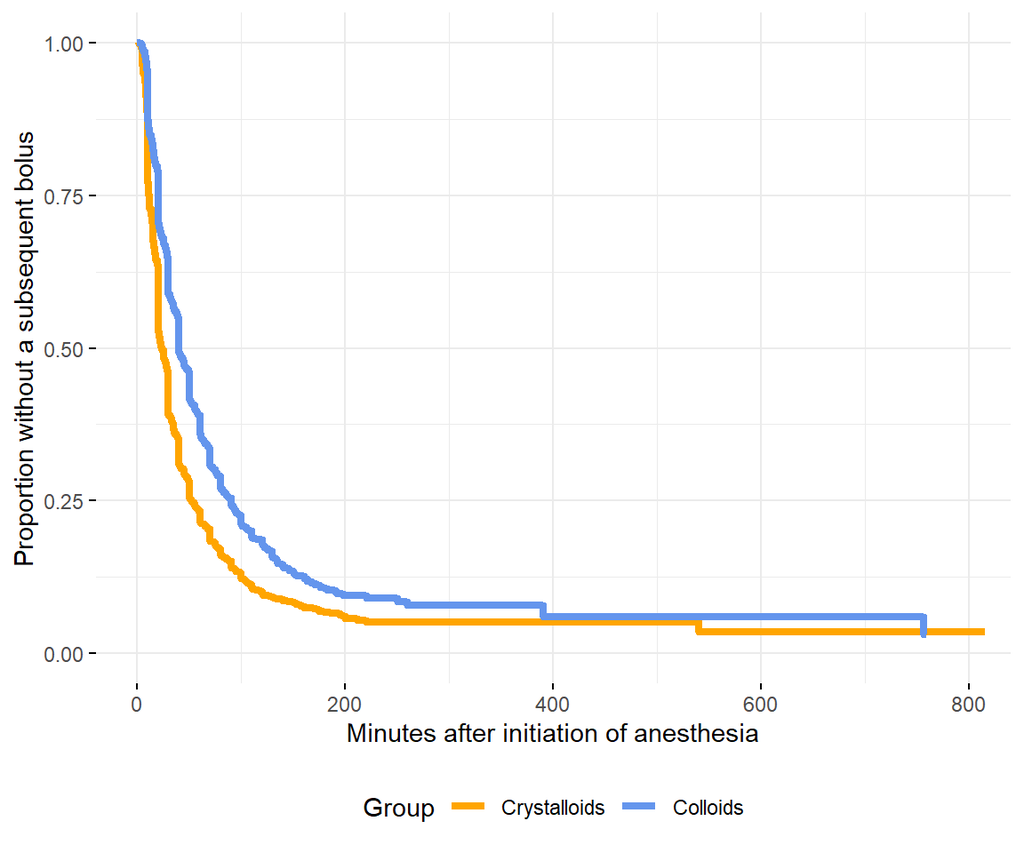

The proportion of bolus administrations plotted against the duration until a subsequent bolus administration or the end of the procedure. This figure includes repeated bolus administrations within a patient (N = 4,890 administrations). Using a shared frailty model, we found that the risk of requiring a subsequent bolus was lower in the colloids group.

### Figure 4: Effects of colloids by categorized bolus number

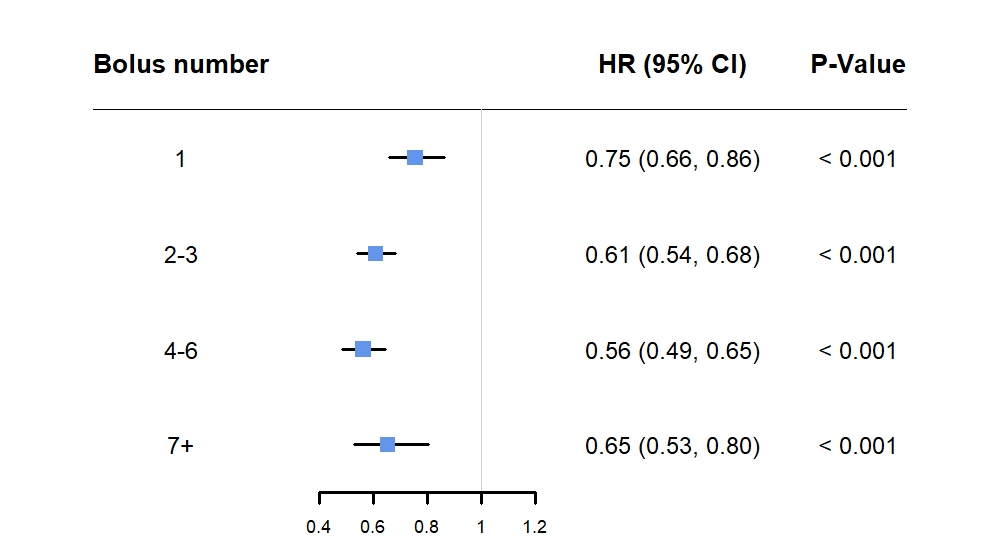

A frailty model was created to test interactions between the choice of fluid and the categorized sequential bolus number. The overall interaction was determined to be statistically significant (P = 0.03) and one pairwise comparison (1 vs 4-6, P = 0.003) was found to be significant at the α=0.5/6=0.008 level.

### Figure 5: Distribtuion of ARV of MAP

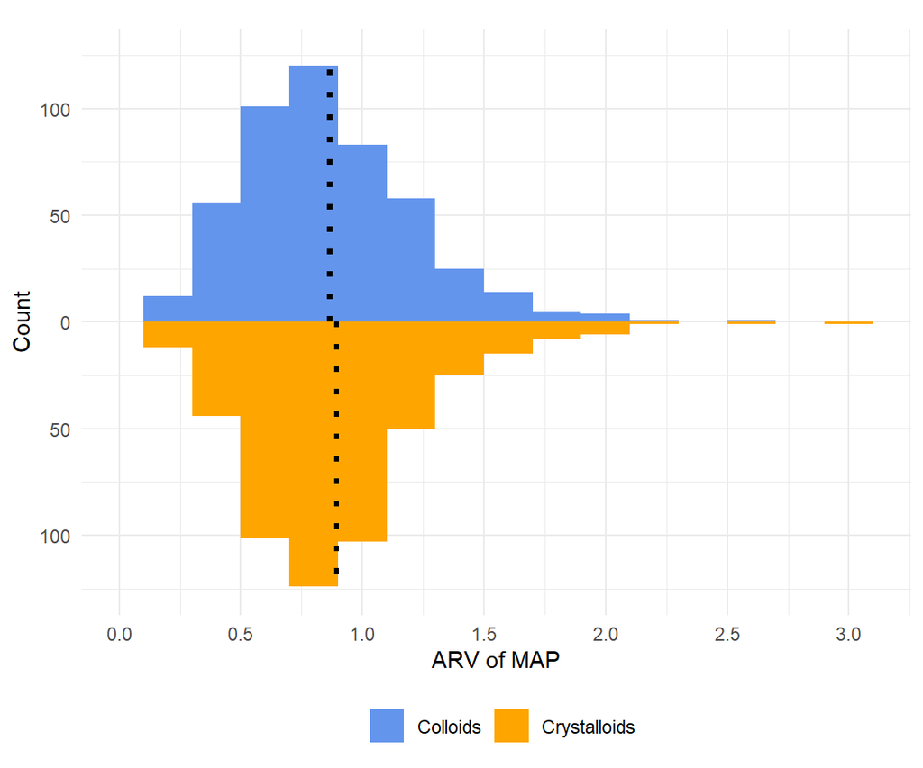

The generalized average real variation of mean arterial is plotted by group. Group means are given as dotted lines. Dotted lines represent group means. We did not detect a difference in ARV of MAP using a linear model. A total of 971 observations were used.

### Figure 6: Subgroup interactions

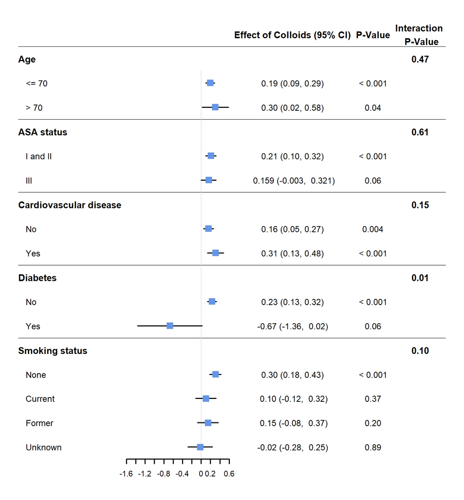

The primary analysis (linear model of TWA of CI by group) was refit with interaction terms between the choice of fluids and several subgroups. The treatment effects, 95% confidence intervals, and P-values are given for each subgroup as well as the overall interaction P-value. Heterogeneity of treatment was detected across diabetes and smoking statuses at the α=0.15 level. No pairwise differences were detected between smoking statuses using a significance criterion of α=0.5/6=0.008. The sample sizes used were 973 for age, 965 for ASA status, 968 for cardiovascular disease, 933 for diabetes, and 973 for smoking status.

### Citations

1. Barbara Kabon, Daniel I. Sessler, Andrea Kurz, on behalf of the Crystalloid–Colloid Study Team; Effect of Intraoperative Goal-directed Balanced Crystalloid versus Colloid Administration on Major Postoperative Morbidity: A Randomized Trial. Anesthesiology 2019;130(5):728-744.
2. Mascha EJ, Yang D, Weiss S, Sessler DI. Intraoperative Mean Arterial Pressure Variability and 30-day Mortality in Patients Having Noncardiac Surgery. Anesthesiology. 2015 Jul;123(1):79-91.
3. Schulte PJ, Mascha EJ. Propensity Score Methods: Theory and Practice for Anesthesia Research. Anesth Analg. 2018 Oct;127(4):1074-1084.